# R Example

maashaw

Started on 2023-03-23; This report compiled 2023-03-31T01:39:25+0100

# 1 Preface

Junior Doctors working in the NHS have seen their pay fall substantially in the last 15 years; when adjusted for inflation, F1s have seen pay cuts of 26%. This has happened because of a deliberate decision on the part of the british government to grant below-inflation pay rises.

Because Junior Doctors progress through training grades with with increasing responsibilities and pay, many have not seen their pay fall in real terms, but their pockets are emptier than their colleagues who came before them. At the same time, the costs of living and training have continued to raise, and the scope and clinical complexity of medical care have only increased.

This repo brings together a number of different resources to help people who are interested in these subjects to explore the underlying data.

# 2 Graph.R

This file creates some graphs to illustrate how doctors’ pay has fallen. You might find it useful as a starting point for further exploration.

## 2.1 RMarkdown

This example file includes RMarkdown content, so that you can easily create beautiful reports and documents using Markdown formatting. In RStudio, you can use File > Compile Report… to generate a document.

## 2.2 Github

Make something cool? Spotted something dumb? Feel free to send a pull request.

# 3 Graph

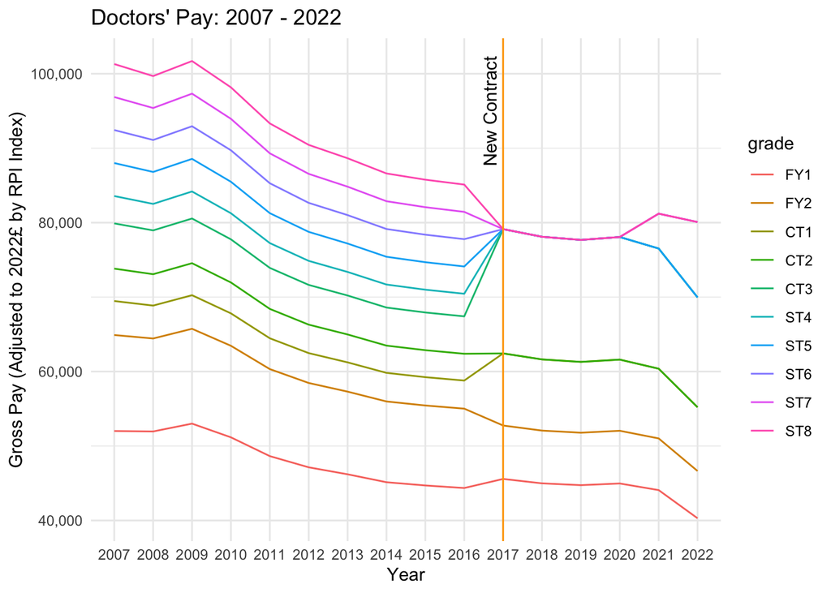

```r
library(ggplot2) #Make nice plots
library(readr)   #Import CSVs

importTab <- function(fname){
  # This little helper function makes it easier to import CSV Tables
  # It requires a csv with size x, y with row and column titles formatted as so:
  # |       x | Title A | Title B | ...
  # | Title 1 |       1 |       2 | ...
  # | Title 2 |       4 |       5 | ...
  #     ...       ...       ...
  # And reformats it as an transposed tibble of y-1,x-1 size,
  # with row and column names set by the first row and column, e.g.
  # |       x | Title 1 | Title 2 | ...
  # | Title A |       1 |       4 | ...
  # | Title B |       2 |       5 | ...
  #     ...       ...       ...
  t1 <- read_csv(fname, show_col_types = FALSE)
  t2 <- data.table::transpose(t1[,-1])
  colnames(t2) <- unlist(t1[,1])
  rownames(t2) <- colnames(t1)[-1]
  return(t2)
}

getWeekendMulti <- function(weekends){
  # Brief helper function to return the weekend multiplier for a given
  # Weekend frequency; e.g. for 1:4 weekends, weekends = 4, returns 0.06
  weekendMulti <- c(0.15,  0.1, 0.075, 0.06, 0.05, 0.04, 0.03, 0)
  cutoffs      <- c(   2,    3,     4,    5,    6,    7,    8)
  return(weekendMulti[findInterval(weekends, cutoffs, left.open = TRUE) +1])
}

calcPay2002 <- function(base, banding){
  # Calculates pay under the 2002 contract
  # base    (numeric) - base pay
  # banding (numeric) - banding multiplier (e.g. for 50%, 0.50)
  # Unbanded:       <40h/wk                      - 0.0
  # 1A:  >40h but <= 48h/wk,     most antisocial - 0.5
  # 1B:  >40h but <= 48h/wk, moderate antisocial - 0.4
  # 1C:  >40h but <= 48h/wk,    least antisocial - 0.2
  # 2A:  >48h but <= 56h/wk,     most antisocial - 0.8
  # 2B:  >48h but <= 56h/wk,    least antisocial - 0.5
  #  3:  >56h or not achieving rest requirements - 1.0
  # You may have noticed that it is undefined which band a practitioner working
  # exactly 40h/wk should fall into. This appears to be how the contract is
  # worded (pp 15-18, TCS 2002 version 10, March 2013).
  # The exact banding definitions depend on the on-call and weekend frequencies,
  # as well as the proportion of hours.
  # However, anecdotally most posts on the 2002 contract attracted 1A or 2B
  # banding supplements.
  return(base * (1+ banding))
}

calcPay2016 <- function(base, addHours, supHours, weekends, nroc = 0){
  # Calculates pay under the 2016 contact
  # base     (numeric) - base pay
  # addHours (numeric) - additional total weekly hours beyond 40/wk
  # supHours (numeric) - number of weekly unsociable hours at enhanced rate
  # nroc     (numeric) - NROC supplement, if any, or 0 (usually 0)
  # weekends (numeric) - 1:frequency of weekends (e.g. for 1:4 weekends, 4)
  addHoursMulti  <- 1/40 * addHours           # additional hours fraction
  supHoursMulti  <- 1/40 * 0.37 * supHours    # enhanced rate is 1.37 time
  weekendMulti   <- getWeekendMulti(weekends) # Look up the weekend multiplier
  pay <- base * (1 + addHoursMulti + supHoursMulti + weekendMulti) + nroc
  return(pay)
}

calcPay <- function(grade, year, banding, addHours, supHours, weekends, nrocNode = 0){
  # Calculates gross pay for a particular grade in a particular year
  #   - grade is a string matching one of the grades in the table's labels, or an
  #     index into the table (e.g. "FY1" or 1).
  #   - year is an integer in the range 2007:2022
  #   - banding is a banding multiplier and is applied if the post falls under the
  #     2002 contract (e.g. year is <= 2016)
  # The following are considered if the post falls under the 2016 contract
  #   (e.g. the year is > 2016)
  #   - addHours is a number representing the additional hours per week over 40
  #   - supHours is a number representing the number of weekly hours attracting
  #     enhanced rates
  #   - weekends is a number representing the weekend frequency (e.g. 1:4 -> 4)
  #   - nrocNode is a number representing the nodal point for non-resident on-calls
  #     NB this is different from the calcPay2016, which asks for a cash value
  #     whereas this function will look it up for you in the NROC table.
  # Year is an integer in the range 2007:2022
  base <- Pay[as.character(year), grade]
  nrocPay <- 0
  if(year <= 2016){
    return(calcPay2002(base, banding))
  }
  else if (nrocNode > 0){
    nrocPay <- NROC[as.character(year), nrocNode]
  }
  return(calcPay2016(base, addHours, supHours, weekends, nrocPay))
}

inflate <- function(baseYear, cashYear, value, metric){
  # Calculates the inflation-adjusted value of money which is paid in cashYear
  # in the value of baseYear money; e.g. if I'm paid £10 in 2008, how much would
  # that be worth in 2022, using the RPI metric (about £16)
  # baseYear is an integer in the range 2007:2022 - which year's money do you
  #   want to express the equivalent value in?
  # cashYear is an integer in the range 2007:2022 - which year's money is the
  #   input value expressed in?
  # value is the sum of money in the cashYear
  # metric is a string referencing a column label in 'Inflation'
  #  - "RPI" uses the ONS's Retail Price Index measure of inflation
  #  - "CPI" uses the ONS's Consumer Price Index measure of inflation
  #  - "Freddo" uses the value of a freddo over time as a single-item basket of
  #      goods for a measure of inflation. Like RPI, but Principally for
  #      illustration or humerous effect.
  inflationMulti <- Inflation[as.character(baseYear), metric] / Inflation[as.character(cashYear), metric]
  return(inflationMulti * value)
}

tabApply <- function(tab, f, x = NULL, out = "tab"){
  # Helper function for applying a function to the whole table
  # tab - table to work on
  # f   - function to apply, of the form f(tab, row, column, var)
  # x   - control variable to pass to function
  tab.x <- lengths(tab)[1]  # e.g. cols; Assumes array's rectangular, not ragged
  tab.y <- length(tab)      # e.g. rows;
  outDF <- data.frame()

  # Apologies, this is definitely the C++ way, not the R way
  for(i in 1:tab.y){        # for each column
    for(j in 1:tab.x){      # for each row
      if(out == "tab"){
        tab[j,i] <- f(tab, j, i, x)
      }
      else if(out == "DF"){
        outDF <- rbind(outDF, f(tab, j, i, x))
      }
    }
  }
  if(out == "tab"){ return(tab) }
  else if(out == "DF"){return(outDF)}
}

tabCalcPay <- function(tab, j, i, x){
  v <- calcPay( colnames(tab)[i],
                rownames(tab)[j],
                0.5,
                10, 5, 4, 0)
  return(v)
}

tabInflate <- function(tab, j, i, x){
  v <- inflate(x[1],
               rownames(tab)[j],
               tab[j,i],
               x[2])
  return(v)
}

tabDF <- function(tab, j, i, x){
  v <- list(colnames(tab)[i],
          rownames(tab)[j],
          tab[j,i])
  return(v)
}

Pay <- importTab("RData/Pay.csv")
Inflation <- importTab("RData/Inflation.csv")
NROC <- importTab("RData/NROC.csv")

payGross <- tabApply(Pay, tabCalcPay)
payGross.2022 <- tabApply(payGross, tabInflate, c(2022, "RPI"))
payGross.2022.DF <- tabApply(payGross.2022, tabDF, out="DF")

colnames(payGross.2022.DF) <- c("grade", "year", "pay")
payGross.2022.DF$grade <- factor(payGross.2022.DF$grade, levels = colnames(Pay))

ggplot(data=payGross.2022.DF, aes(x=year, y=pay, group=grade)) +
  geom_line(aes(color=grade)) +
  scale_y_continuous(name = "Gross Pay (Adjusted to 2022£ by RPI Index)", labels = scales::comma) +
  scale_x_discrete(name = "Year") +
  ggtitle("Doctors' Pay: 2007 - 2022") +
  annotate(geom = "text", x = '2017', y = 95000, label = "New Contract", angle=90, vjust = -0.5 ) +
  geom_vline(xintercept = '2017', color = 'orange') +
  theme_minimal()
```